# Model Performance Analysis

Samuel N. Araya

26 June, 2019

# XBRT Model Performances

The testing set was split based on random unique combinations of date and transect without replacement into approximately 0.75:0.25 training:testing set split (i.e., 300:100 records).

The testing set was used as a hold-out set and used only to evaluate final trained models. The testing set was subset based on random unique combinations of three sampling dates and two transects without replacement. This method was adopted to ensure that the testing and training samples were not too similar because of spatial autocorrelation, which would result if a simple random splitting was done. Furthermore, to check for possible bias that may result from training:testing set split, we randomly generated 30 unique training-testing set splits and trained 30 models based on the 30 training sets and tested the model performance on their respective testing sets.

## Model Performances Summaries

### Absolute Residual of models sorted by MAE

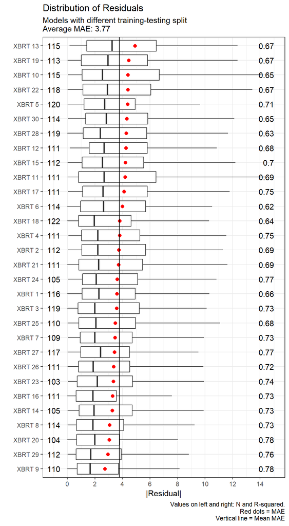

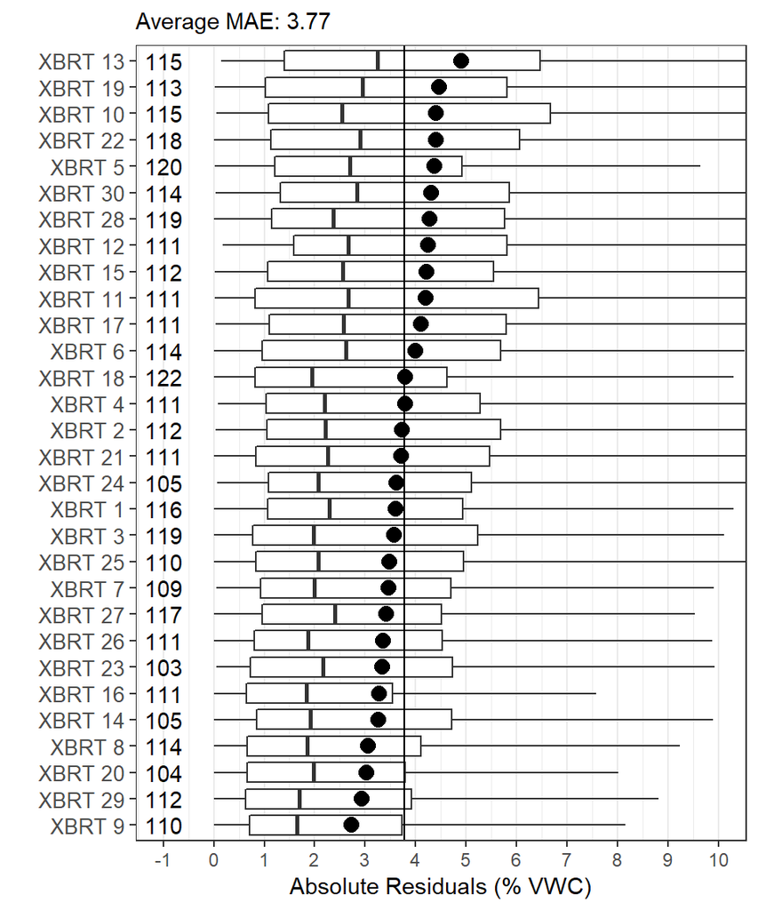

### Predicted vs. Measured Plot

Combined one to one plot with ensemble performance metrics

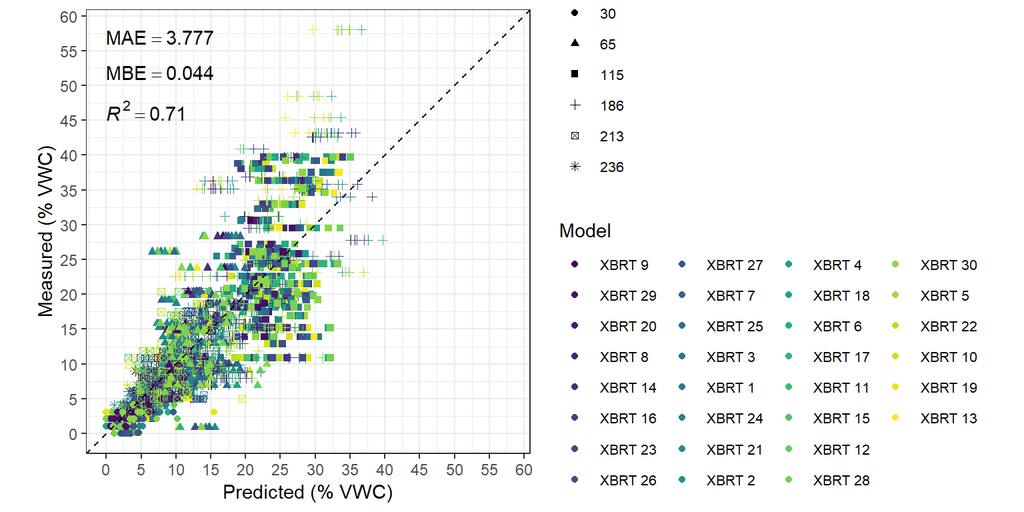

Individual models: Color plot

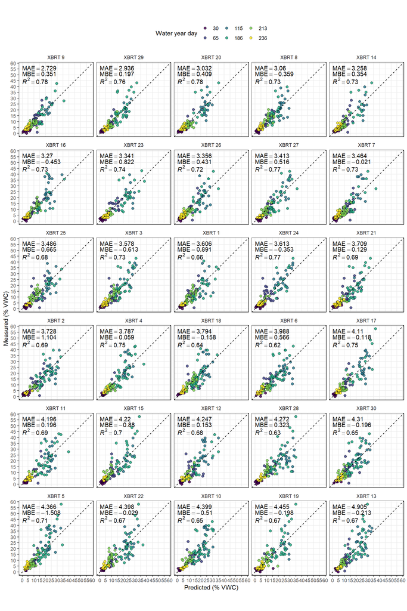

Individual models: Black and white

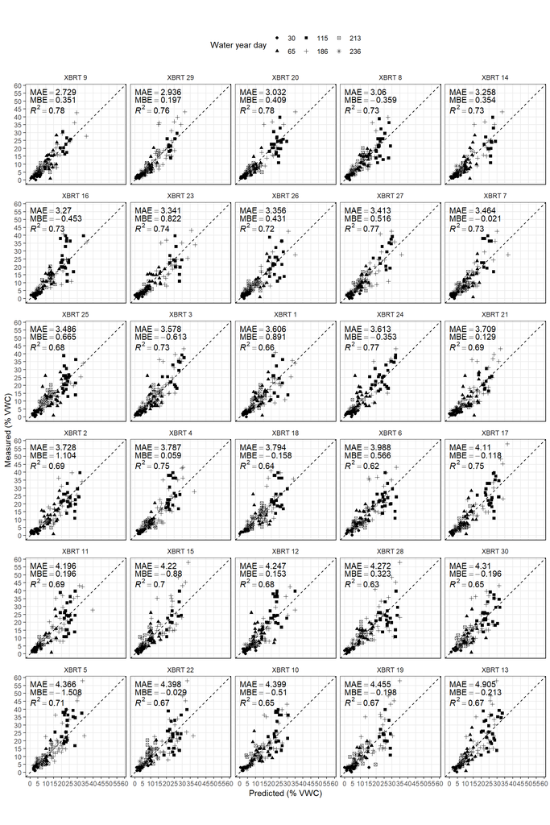

### Variable Importance

Permutation based variable importance calculated as loss from feature dropout.

Top 25 Variables

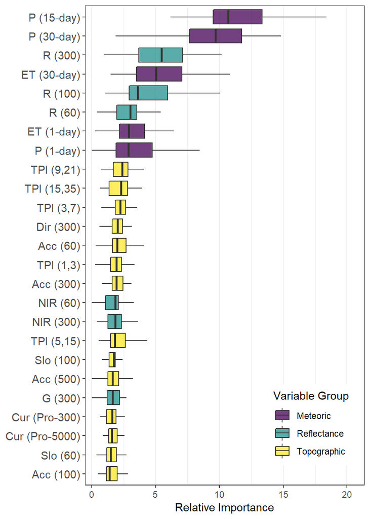

Summation of all variables grouped by type

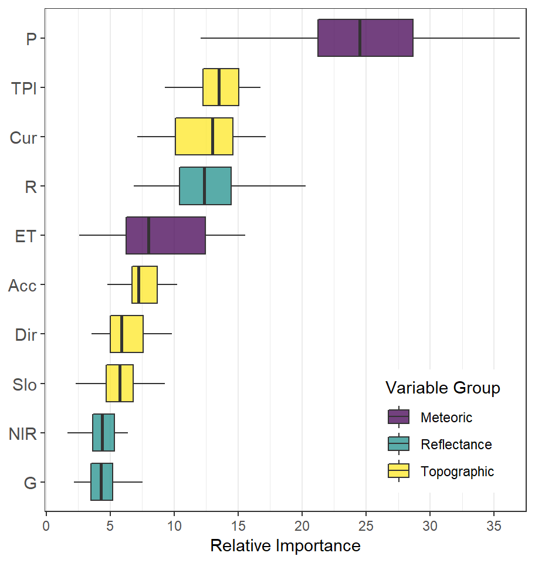

Mean of all variables grouped by type

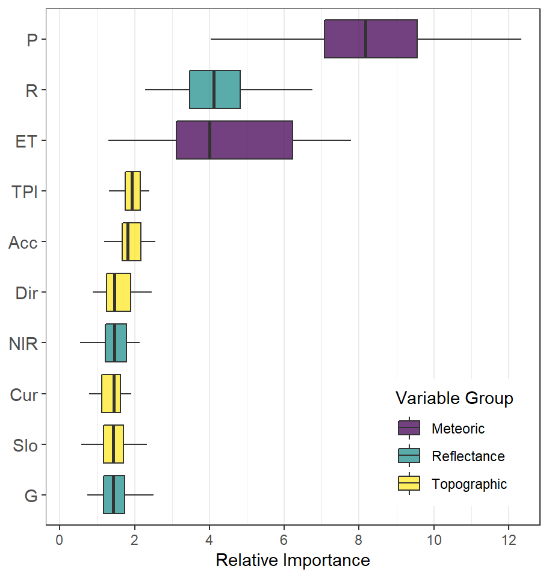

### Variable Effect

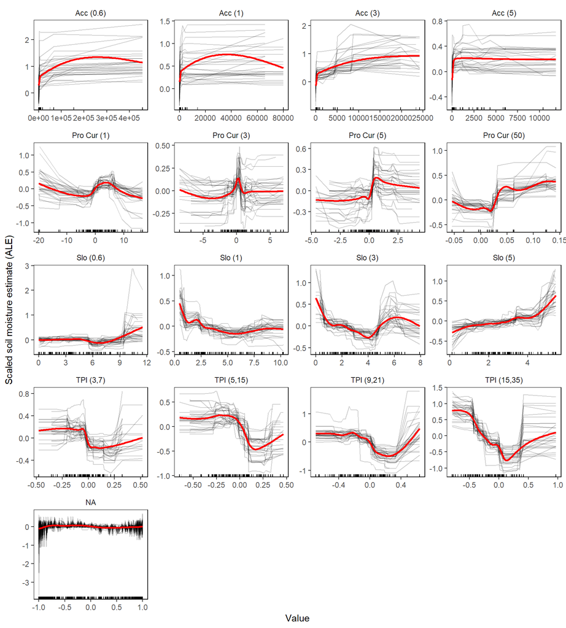

#### Tuning summaries for best models

Best tuning parameters

| id | nrounds | max_depth | eta | gamma | colsample_bytree | min_child_weight | subsample | label | label_ordered |
| --- | --- | --- | --- | --- | --- | --- | --- | --- | --- |
| 1 | 700 | 4 | 0.02 | 0 | 0.2 | 1 | 1.0 | XBRT 1 | XBRT 1 |
| 2 | 4800 | 3 | 0.02 | 0 | 0.2 | 1 | 0.8 | XBRT 2 | XBRT 2 |
| 3 | 600 | 3 | 0.02 | 1 | 0.2 | 1 | 0.9 | XBRT 3 | XBRT 3 |
| 4 | 450 | 3 | 0.02 | 0 | 0.2 | 1 | 0.8 | XBRT 4 | XBRT 4 |
| 5 | 450 | 3 | 0.02 | 0 | 0.4 | 1 | 0.8 | XBRT 5 | XBRT 5 |
| 6 | 4800 | 3 | 0.02 | 0 | 0.2 | 1 | 0.9 | XBRT 6 | XBRT 6 |
| 7 | 500 | 3 | 0.02 | 0 | 0.2 | 1 | 0.8 | XBRT 7 | XBRT 7 |
| 8 | 550 | 3 | 0.02 | 1 | 0.2 | 1 | 0.8 | XBRT 8 | XBRT 8 |
| 9 | 450 | 3 | 0.02 | 0 | 0.2 | 1 | 0.8 | XBRT 9 | XBRT 9 |
| 10 | 3000 | 3 | 0.02 | 0 | 0.2 | 1 | 0.8 | XBRT 10 | XBRT 10 |
| 11 | 500 | 3 | 0.02 | 0 | 0.2 | 1 | 0.8 | XBRT 11 | XBRT 11 |
| 12 | 900 | 3 | 0.02 | 0 | 0.2 | 1 | 0.8 | XBRT 12 | XBRT 12 |
| 13 | 550 | 4 | 0.02 | 1 | 0.2 | 1 | 1.0 | XBRT 13 | XBRT 13 |
| 14 | 500 | 3 | 0.02 | 1 | 0.4 | 1 | 0.8 | XBRT 14 | XBRT 14 |
| 15 | 1200 | 3 | 0.02 | 0 | 0.2 | 1 | 0.8 | XBRT 15 | XBRT 15 |
| 16 | 650 | 3 | 0.02 | 1 | 0.2 | 1 | 1.0 | XBRT 16 | XBRT 16 |
| 17 | 1300 | 3 | 0.02 | 1 | 0.4 | 1 | 0.8 | XBRT 17 | XBRT 17 |
| 18 | 4200 | 3 | 0.02 | 1 | 0.2 | 1 | 0.9 | XBRT 18 | XBRT 18 |
| 19 | 1600 | 3 | 0.02 | 0 | 0.2 | 1 | 0.8 | XBRT 19 | XBRT 19 |
| 20 | 650 | 3 | 0.02 | 0 | 0.2 | 1 | 0.8 | XBRT 20 | XBRT 20 |
| 21 | 3300 | 3 | 0.02 | 0 | 0.2 | 1 | 0.8 | XBRT 21 | XBRT 21 |
| 22 | 650 | 3 | 0.02 | 1 | 0.2 | 1 | 0.8 | XBRT 22 | XBRT 22 |
| 23 | 1400 | 3 | 0.02 | 0 | 0.2 | 1 | 0.9 | XBRT 23 | XBRT 23 |
| 24 | 800 | 3 | 0.02 | 0 | 0.2 | 1 | 0.8 | XBRT 24 | XBRT 24 |
| 25 | 900 | 4 | 0.02 | 0 | 0.2 | 1 | 0.8 | XBRT 25 | XBRT 25 |
| 26 | 450 | 3 | 0.02 | 0 | 0.2 | 1 | 0.9 | XBRT 26 | XBRT 26 |
| 27 | 450 | 3 | 0.02 | 0 | 0.2 | 1 | 0.8 | XBRT 27 | XBRT 27 |
| 28 | 4500 | 3 | 0.02 | 0 | 0.2 | 1 | 0.8 | XBRT 28 | XBRT 28 |
| 29 | 600 | 3 | 0.02 | 0 | 0.2 | 1 | 0.8 | XBRT 29 | XBRT 29 |
| 30 | 3900 | 3 | 0.02 | 0 | 0.2 | 1 | 0.8 | XBRT 30 | XBRT 30 |

Tuning plots

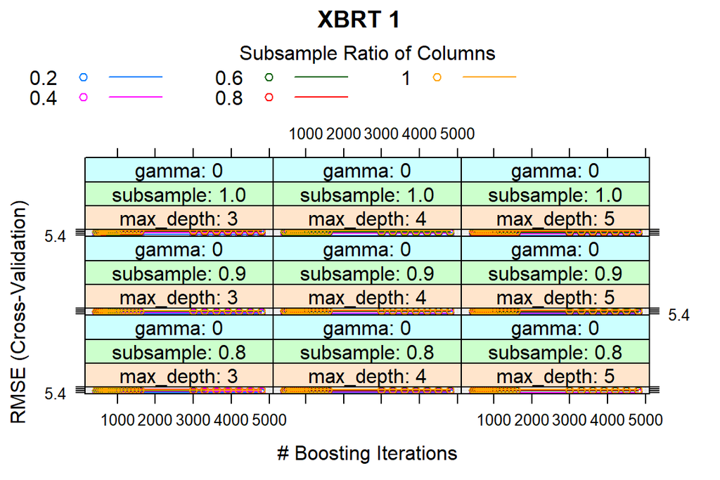

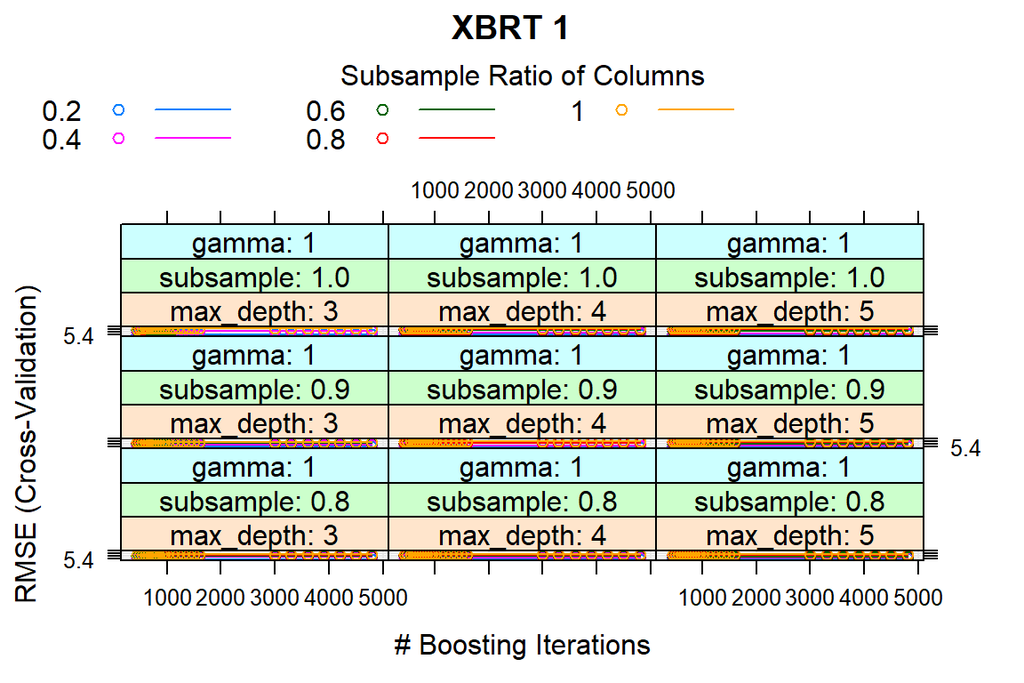

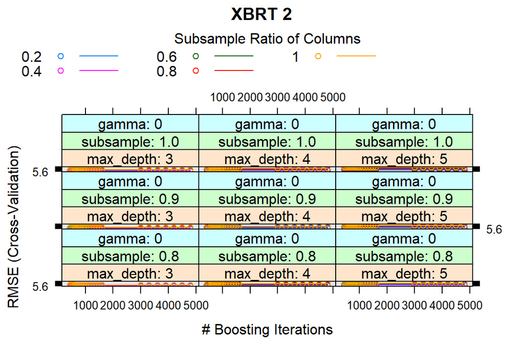

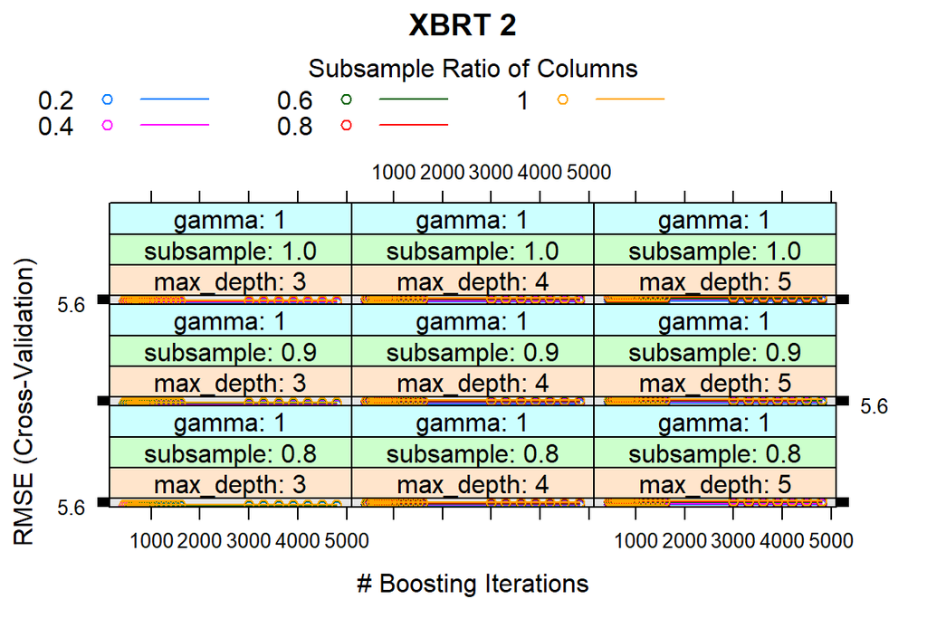

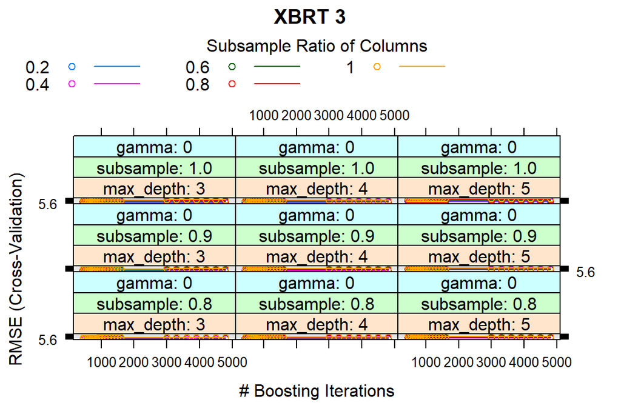

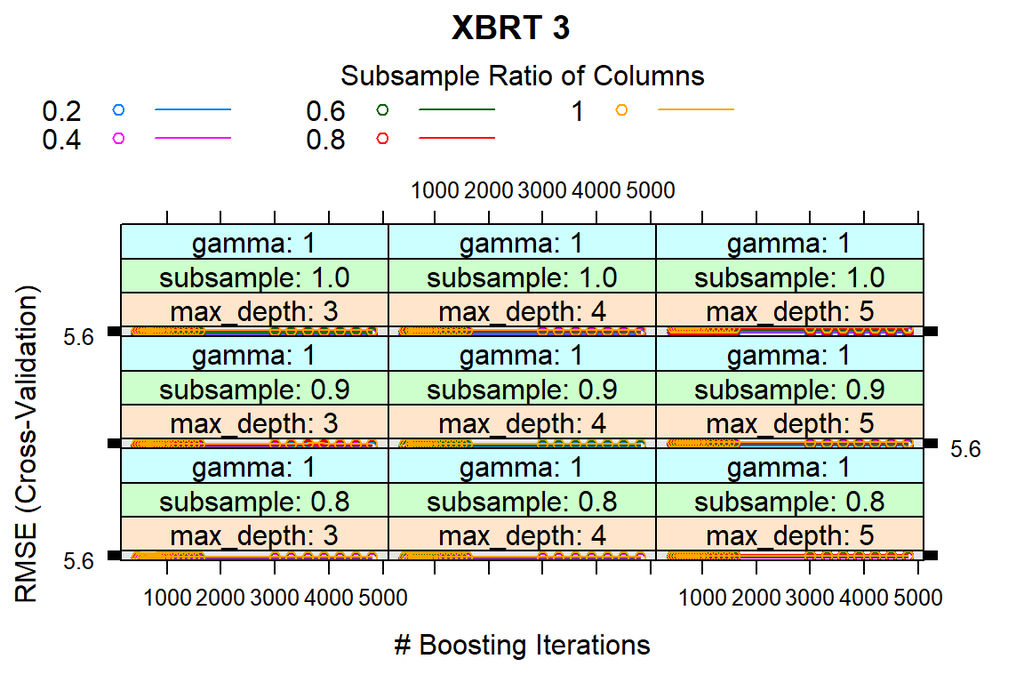

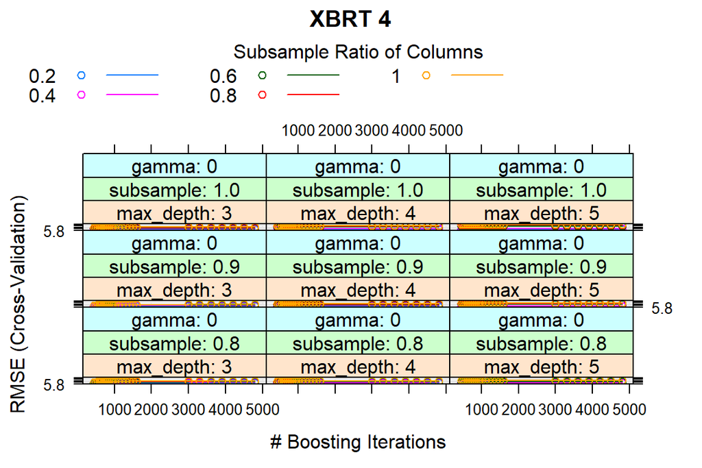

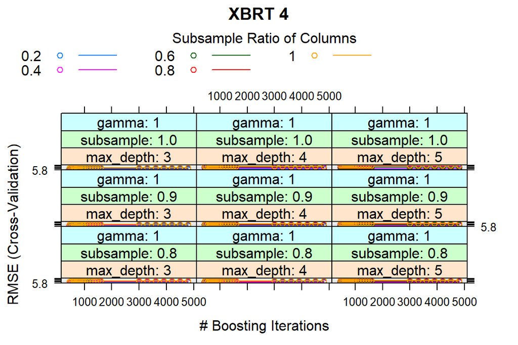

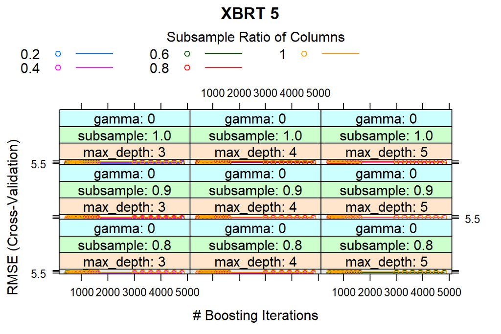

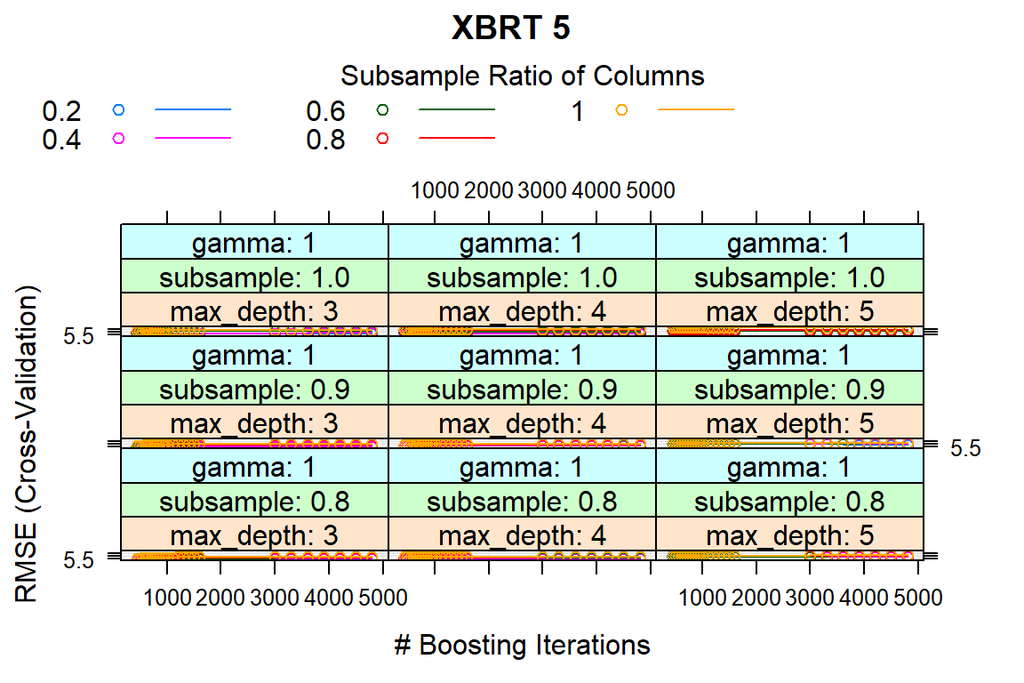

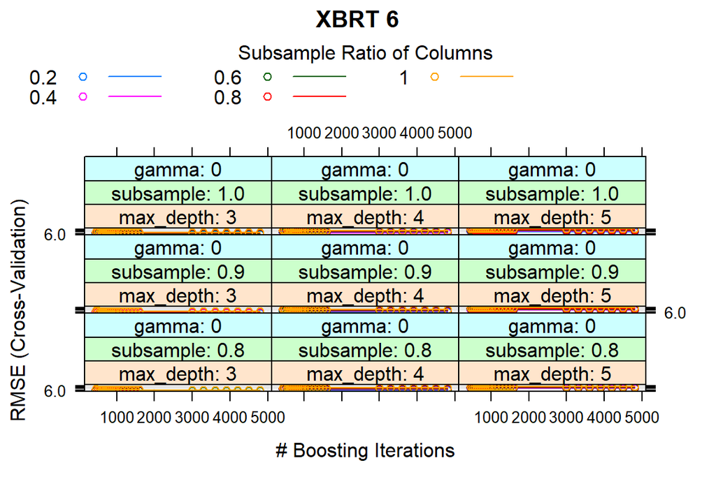

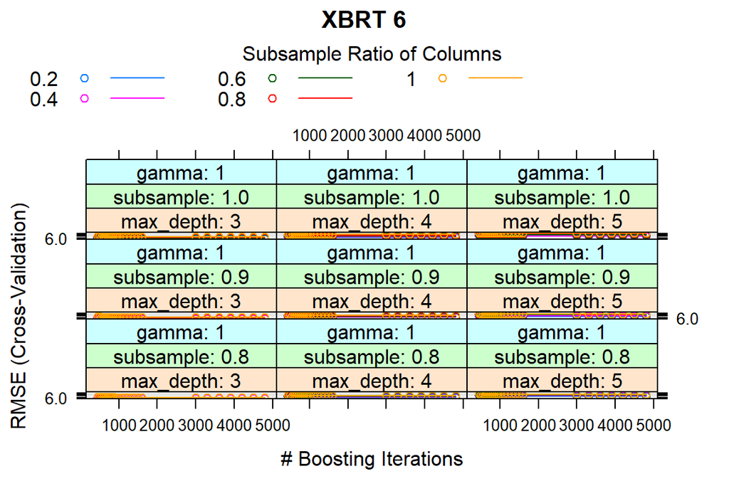

[48 more figures not shown]

## Detailed Model Performances

| label | rmse | mae | mbe | r2 | r2.fmt | n | res_q1 | res_q3 | res_iqr | mae_txt | mbe_txt | r2_txt | label_ordered |
| --- | --- | --- | --- | --- | --- | --- | --- | --- | --- | --- | --- | --- | --- |
| XBRT 1 | 5.2818 | 3.6058 | 0.8915 | 0.6575 | 0.66 | 116 | -1.0123 | 3.1442 | 4.1566 | MAE==3.606 | MBE==0.891 | italic(R) ^ 2 == 0.66 | XBRT 1 |
| XBRT 10 | 6.3507 | 4.3992 | -0.5101 | 0.6486 | 0.65 | 115 | -2.5687 | 2.3537 | 4.9224 | MAE==4.399 | MBE==-0.51 | italic(R) ^ 2 == 0.65 | XBRT 10 |
| XBRT 11 | 6.0792 | 4.1964 | 0.1962 | 0.6948 | 0.69 | 111 | -1.4548 | 3.2512 | 4.7060 | MAE==4.196 | MBE==0.196 | italic(R) ^ 2 == 0.69 | XBRT 11 |
| XBRT 12 | 5.8095 | 4.2471 | 0.1534 | 0.6836 | 0.68 | 111 | -2.1929 | 3.0313 | 5.2242 | MAE==4.247 | MBE==0.153 | italic(R) ^ 2 == 0.68 | XBRT 12 |
| XBRT 13 | 7.0561 | 4.9052 | -0.2126 | 0.6653 | 0.67 | 115 | -2.0934 | 3.7001 | 5.7935 | MAE==4.905 | MBE==-0.213 | italic(R) ^ 2 == 0.67 | XBRT 13 |
| XBRT 14 | 4.8787 | 3.2576 | 0.3542 | 0.7301 | 0.73 | 105 | -1.2503 | 2.7601 | 4.0104 | MAE==3.258 | MBE==0.354 | italic(R) ^ 2 == 0.73 | XBRT 14 |
| XBRT 15 | 6.2318 | 4.2198 | -0.8804 | 0.6979 | 0.70 | 112 | -2.5233 | 2.5633 | 5.0866 | MAE==4.22 | MBE==-0.88 | italic(R) ^ 2 == 0.7 | XBRT 15 |
| XBRT 16 | 5.2584 | 3.2701 | -0.4526 | 0.7277 | 0.73 | 111 | -1.7833 | 1.8004 | 3.5837 | MAE==3.27 | MBE==-0.453 | italic(R) ^ 2 == 0.73 | XBRT 16 |
| XBRT 17 | 5.8060 | 4.1101 | -0.1180 | 0.7528 | 0.75 | 111 | -2.1705 | 2.9363 | 5.1068 | MAE==4.11 | MBE==-0.118 | italic(R) ^ 2 == 0.75 | XBRT 17 |
| XBRT 18 | 5.8661 | 3.7941 | -0.1584 | 0.6365 | 0.64 | 122 | -1.6112 | 2.4466 | 4.0578 | MAE==3.794 | MBE==-0.158 | italic(R) ^ 2 == 0.64 | XBRT 18 |
| XBRT 19 | 6.6036 | 4.4550 | -0.1981 | 0.6696 | 0.67 | 113 | -2.5266 | 2.9646 | 5.4912 | MAE==4.455 | MBE==-0.198 | italic(R) ^ 2 == 0.67 | XBRT 19 |
| XBRT 2 | 5.2406 | 3.7277 | 1.1043 | 0.6924 | 0.69 | 112 | -1.0398 | 3.8791 | 4.9188 | MAE==3.728 | MBE==1.104 | italic(R) ^ 2 == 0.69 | XBRT 2 |
| XBRT 20 | 4.6236 | 3.0325 | 0.4089 | 0.7789 | 0.78 | 104 | -0.7013 | 2.6555 | 3.3568 | MAE==3.032 | MBE==0.409 | italic(R) ^ 2 == 0.78 | XBRT 20 |
| XBRT 21 | 5.4595 | 3.7087 | 0.1294 | 0.6858 | 0.69 | 111 | -1.5832 | 2.9964 | 4.5796 | MAE==3.709 | MBE==0.129 | italic(R) ^ 2 == 0.69 | XBRT 21 |
| XBRT 22 | 6.2828 | 4.3979 | -0.0293 | 0.6700 | 0.67 | 118 | -2.9406 | 2.7552 | 5.6958 | MAE==4.398 | MBE==-0.029 | italic(R) ^ 2 == 0.67 | XBRT 22 |
| XBRT 23 | 5.0794 | 3.3413 | 0.8222 | 0.7389 | 0.74 | 103 | -0.7590 | 2.8342 | 3.5932 | MAE==3.341 | MBE==0.822 | italic(R) ^ 2 == 0.74 | XBRT 23 |
| XBRT 24 | 5.0888 | 3.6129 | -0.3525 | 0.7719 | 0.77 | 105 | -1.9928 | 2.0771 | 4.0699 | MAE==3.613 | MBE==-0.353 | italic(R) ^ 2 == 0.77 | XBRT 24 |
| XBRT 25 | 5.0537 | 3.4864 | 0.6650 | 0.6822 | 0.68 | 110 | -1.3370 | 3.0176 | 4.3547 | MAE==3.486 | MBE==0.665 | italic(R) ^ 2 == 0.68 | XBRT 25 |
| XBRT 26 | 5.0513 | 3.3564 | 0.4305 | 0.7221 | 0.72 | 111 | -1.3863 | 2.1990 | 3.5853 | MAE==3.356 | MBE==0.431 | italic(R) ^ 2 == 0.72 | XBRT 26 |
| XBRT 27 | 4.7997 | 3.4134 | 0.5158 | 0.7712 | 0.77 | 117 | -1.3534 | 2.7442 | 4.0975 | MAE==3.413 | MBE==0.516 | italic(R) ^ 2 == 0.77 | XBRT 27 |
| XBRT 28 | 6.4903 | 4.2717 | 0.3234 | 0.6262 | 0.63 | 119 | -2.1308 | 2.4767 | 4.6075 | MAE==4.272 | MBE==0.323 | italic(R) ^ 2 == 0.63 | XBRT 28 |
| XBRT 29 | 4.6607 | 2.9362 | 0.1968 | 0.7605 | 0.76 | 112 | -0.7309 | 2.3465 | 3.0774 | MAE==2.936 | MBE==0.197 | italic(R) ^ 2 == 0.76 | XBRT 29 |
| XBRT 3 | 5.2902 | 3.5779 | -0.6125 | 0.7341 | 0.73 | 119 | -1.7673 | 2.1192 | 3.8865 | MAE==3.578 | MBE==-0.613 | italic(R) ^ 2 == 0.73 | XBRT 3 |
| XBRT 30 | 6.0501 | 4.3101 | -0.1958 | 0.6462 | 0.65 | 114 | -2.8401 | 2.7700 | 5.6101 | MAE==4.31 | MBE==-0.196 | italic(R) ^ 2 == 0.65 | XBRT 30 |
| XBRT 4 | 5.4833 | 3.7874 | 0.0591 | 0.7489 | 0.75 | 111 | -1.3942 | 2.6291 | 4.0232 | MAE==3.787 | MBE==0.059 | italic(R) ^ 2 == 0.75 | XBRT 4 |
| XBRT 5 | 6.5061 | 4.3665 | -1.5081 | 0.7070 | 0.71 | 120 | -2.8090 | 2.1716 | 4.9806 | MAE==4.366 | MBE==-1.508 | italic(R) ^ 2 == 0.71 | XBRT 5 |
| XBRT 6 | 5.9114 | 3.9883 | 0.5661 | 0.6173 | 0.62 | 114 | -1.5762 | 3.4472 | 5.0234 | MAE==3.988 | MBE==0.566 | italic(R) ^ 2 == 0.62 | XBRT 6 |
| XBRT 7 | 5.0555 | 3.4644 | -0.0211 | 0.7319 | 0.73 | 109 | -1.7670 | 2.0694 | 3.8364 | MAE==3.464 | MBE==-0.021 | italic(R) ^ 2 == 0.73 | XBRT 7 |
| XBRT 8 | 4.6597 | 3.0599 | -0.3589 | 0.7269 | 0.73 | 114 | -1.9600 | 1.7319 | 3.6919 | MAE==3.06 | MBE==-0.359 | italic(R) ^ 2 == 0.73 | XBRT 8 |
| XBRT 9 | 3.9282 | 2.7292 | 0.3513 | 0.7818 | 0.78 | 110 | -1.1446 | 2.2307 | 3.3753 | MAE==2.729 | MBE==0.351 | italic(R) ^ 2 == 0.78 | XBRT 9 |